# Simulation 10: DR with case cohort sampling

Brian Richardson

12/10/2024

```r
rm(list = ls())
library(dplyr)
library(tidyverse)
library(ggplot2)
library(ggh4x)
library(kableExtra)
```

```r
# load simulation results from each of 10 clusters
setwd(dirname(getwd()))
sim.out.list <- lapply(
  X = 0:9,
  FUN = function(clust) {
    cbind(clust,
          read.csv(paste0("sim_data/sim10_dr_cc/sd",
                          clust, ".csv")))
  })

# combine simulation results into 1 data frame
sim.out <- bind_rows(sim.out.list)

# true MSM parameters
g <- 0.175

# number of sims per setting
n.rep <- nrow(sim.out) / n_distinct(dplyr::select(sim.out, n, B, vare, pi.cc))

# make long data frame
sim.out.long <- sim.out %>%
  pivot_longer(cols = starts_with("ghat") |
                 starts_with("stde") |
                 starts_with("bste"),
               names_to = "method.param",
               values_to = "val") %>%
    mutate(method = factor(substr(method.param, 6, 6),
                           levels = c("O", "N", "C"),
                           labels = c("Oracle DR",
                                      "Naive DR",
                                      "DR CS")),
           param = factor(substr(method.param, 8, 8)),
           name = factor(substr(method.param, 1, 4)),
           g.true = g[param]) %>%
  dplyr::select(-method.param) %>%
  group_by(clust, n, B, vare, method, pi.cc, param, name) %>%
  mutate(id = row_number()) %>%
  pivot_wider(names_from = name,
              values_from = val,
              id_cols = c(clust, n, B, vare, pi.cc, method,
                          param, g.true, id)) %>%
  mutate(ci.lower = ghat - qnorm(0.975) * stde,
         ci.upper = ghat + qnorm(0.975) * stde,
         ci.cov = g.true >= ci.lower & g.true <= ci.upper,
         bcci.lower = ghat - qnorm(0.975) * bste,
         bcci.upper = ghat + qnorm(0.975) * bste,
         bcci.cov = g.true >= bcci.lower & g.true <= bcci.upper)
```

## Setup

Consider the following setup:

- sample size $n\in\{400,2000\}$,
- two independent confounders $L_1 \sim \textrm{Bernoulli}(0.5), L_2 \sim N(0, 0.16)$
- univariate exposure $A$, where $A|L \sim N(0.1 - 0.1L_1 + 0.3L_2, 0.04)$
- binary outcome $Y$, with $Y|A,L \sim \textrm{Bernoulli}(0.35 + 0.15A + 0.25L_1 + 0.2L_2 + 0.05AL_1 + 0.1AL_2)$
- resulting MSM $\eta(a) = \textrm{E}\{Y(a)\} = \gamma_0 + \gamma_1a$, where $\pmb{\gamma} = (\gamma_0, \gamma_1)^T = (0.475, 0.175)^T$
- mismeasured exposure $A^* = A + \epsilon$, where $\epsilon \sim N(0, 0.02)$

The estimand of interest in these simulations is $\gamma_1$.

## Methods

In these simulations, we compare three methods:

1. Oracle DR
2. Naive DR
3. Corrected DR

Case cohort sampling is used, wherein $A$ and $\pmb{L}$ are collected only for a fraction of cases. This fraction $\pi_{CC}$ is varied in the simulations.

## Results

We first check for simulations with errors.

```r
# summarize proportion of missing data by setting
sim.out.long %>%
  filter(param == 1) %>%
  group_by(method, n, vare, B, pi.cc) %>%
  summarise(prop.error = mean(is.na(ghat))) %>%
  filter(prop.error > 0) %>%
  ungroup()
```

```
## # A tibble: 0 × 6
## # ℹ 6 variables: method <fct>, n <int>, vare <dbl>, B <int>, pi.cc <dbl>,
## #   prop.error <dbl>
```

### Plots of simulation results

Below are boxplots of the empirical distributions of estimators for $\pmb{\gamma}$.

```r
# extract simulation parameters
n <- unique(sim.out$n)
B <- unique(sim.out$B)
vare <- unique(sim.out$vare)

# make labels for plots
n.labs <- paste0("n = ", n)
names(n.labs) <- n

B.labs <- paste0("B = ", B)
names(B.labs) <- B

vare.labs <- paste0("var(e) = ", vare)
names(vare.labs) <- vare

n.labs <- paste0("n = ", n)
names(n.labs) <- n

param.labs <- paste0("\u03b3", c("0", "1", "2", "3"))
names(param.labs) <- 1:4

# colorblind friendly pallette
pal_light <- c('#EE6677', '#228833', '#4477AA', '#CCBB44', '#66CCEE', '#AA3377', '#BBBBBB')
pal_dark <- c('#991122', '#114419', '#223b55', '#6b611d', '#117799', '#55193b', '#5d5d5d')
```

```r
# create plots
make.plot <- function(title = T, y.lim = Inf, vare. = vare) {

  plot <- sim.out.long %>%
    filter(abs(ghat - g.true) < y.lim,
           vare %in% vare.) %>%
    ggplot(
    aes(x = pi.cc,
        y = ghat,
        fill = method,
        color = method)) +
    geom_boxplot() +
    stat_summary(fun = mean,
                 geom = "point",
                 shape = 8,
                 size = 2,
                 orientation = "x",
                 show.legend = F) +
    geom_hline(aes(yintercept = g.true),
               linetype = "dashed",
               color = "orange") +
    facet_wrap(~pi.cc,
               scales = "free_x",
               #scales = "free",
               labeller = labeller(param = param.labs), nrow = 1) +
    labs(y = "Parameter Estimate",
         fill = "Method",
         color = "Method") +
    theme_bw() +
    theme(axis.title.x = element_blank(),
          axis.ticks.x = element_blank(),
          axis.text.x = element_blank(),
          legend.position = "bottom") +
    scale_fill_manual(values = pal_light) +
    scale_color_manual(values = pal_dark)

  if (title) {
    plot <- plot +
      ggtitle(paste0("Empirical Distribution of Parameter Estimates"),
            subtitle = paste0(n.rep, " simulations per setting"))
  }
  return(plot)
}
```

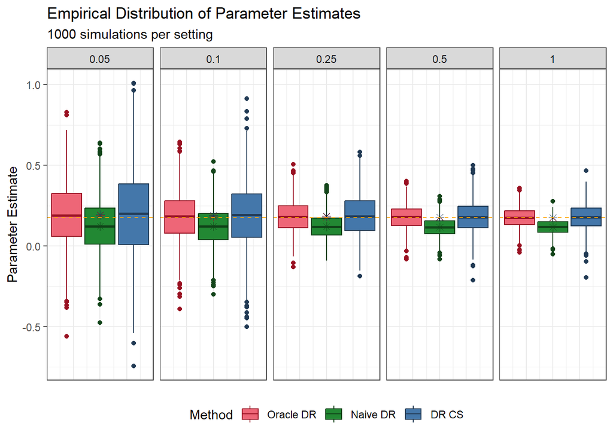

```r
make.plot()
```

### Table of Simulation Results

```r
tbl <- sim.out.long %>%
  mutate(Param = paste0("$\\gamma_", as.numeric(param) - 1, "$")) %>%
  group_by(pi.cc, method) %>%
  mutate(pi.cc = 100 * pi.cc) %>%
  summarise(bias = 100 * mean(ghat - g.true),
            emp.se = 100 * sd(ghat),
            est.se = 100 * mean(stde),
            ci.cov = 100 * mean(ci.cov),
            bcest.se = 100 * mean(bste),
            bcci.cov = 100 * mean(bcci.cov))
kbl <- tbl %>%
  kable(format = "latex",
        digits = c(0, 0,
                   1, 1,
                   1, 1,
                   1, 1),
        align = c(rep("c", 3 + 2),
                  rep("r", 4)),
        booktabs = TRUE,
        linesep = c("", "", "\\addlinespace"),
        escape = FALSE,
        col.names = c("pi.cc", "Method",
                      "Bias", "ESE",
                      "ASE", "Cov",
                      "ASE", "Cov")) %>%
  add_header_above(c(" " = 6,
                     "UC" = 2,
                     "BC" = 2)) %>%
  kable_styling("striped") %>%
  row_spec(row = 0, bold = TRUE)

print(kbl)
```

```
## \begin{table}
## \centering
## \begin{tabular}{cccccrrr}
## \toprule
## \multicolumn{6}{c}{ } & \multicolumn{2}{c}{UC} & \multicolumn{2}{c}{BC} \\
## \cmidrule(l{3pt}r{3pt}){7-8} \cmidrule(l{3pt}r{3pt}){9-10}
## \textbf{pi.cc} & \textbf{Method} & \textbf{Bias} & \textbf{ESE} & \textbf{ASE} & \textbf{Cov} & \textbf{ASE} & \textbf{Cov}\\
## \midrule
## 5 & Oracle DR & 1.5 & 20.7 & 17.1 & 87.0 & 17.3 & 87.5\\
## 5 & Naive DR & -5.2 & 16.7 & 14.1 & 88.6 & 14.3 & 89.0\\
## 5 & DR CS & 1.9 & 27.6 & 23.4 & 88.3 & 23.9 & 89.1\\
## \addlinespace
## 10 & Oracle DR & 0.7 & 15.5 & 13.2 & 89.4 & 13.4 & 89.7\\
## 10 & Naive DR & -5.3 & 12.4 & 10.8 & 88.5 & 10.9 & 88.8\\
## 10 & DR CS & 1.5 & 20.8 & 17.6 & 88.5 & 17.9 & 88.8\\
## \addlinespace
## 25 & Oracle DR & 0.7 & 10.0 & 9.3 & 91.8 & 9.3 & 91.8\\
## 25 & Naive DR & -5.4 & 7.8 & 7.4 & 86.7 & 7.5 & 86.9\\
## 25 & DR CS & 1.1 & 13.2 & 12.2 & 91.4 & 12.2 & 91.6\\
## \addlinespace
## 50 & Oracle DR & 0.4 & 7.7 & 7.2 & 92.6 & 7.3 & 92.6\\
## 50 & Naive DR & -5.7 & 6.2 & 5.8 & 82.3 & 5.8 & 82.4\\
## 50 & DR CS & 0.3 & 10.5 & 9.5 & 90.4 & 9.6 & 90.8\\
## \addlinespace
## 100 & Oracle DR & 0.0 & 6.2 & 6.0 & 94.0 & 6.0 & 94.0\\
## 100 & Naive DR & -5.8 & 4.9 & 4.7 & 76.6 & 4.7 & 76.6\\
## 100 & DR CS & 0.2 & 8.5 & 7.9 & 92.6 & 7.9 & 92.9\\
## \bottomrule
## \end{tabular}
## \end{table}
```